# Week 3 Lecture

## Python Fundamental - Loop, function

#### Author: Yanan Wu ; Date: September, 2024

### 1. Loops and Conditionals

#### 1.1 For Loops

- A for loop can loop can interate over a sequence. The sequence can be a list, a string, or a dictionary
- 'indentation' is part of the loop's block, meaning it get executed every time the loop runs

```python
# Loop list
neighborhoods = ['Indian Hill', 'Burncoat', 'Greendale']

for nei in neighborhoods:
    print(nei)
```

# Loop list neighborhoods = ['Indian Hill', 'Burncoat', 'Greendale'] for nei in neighborhoods: print(nei)

```
Indian Hill
Burncoat
Greendale
```

### Exercise 1: Loop a dictionary

Please loop key, values and items seperately from a dictionary

- loop key
- loop values? (hint: how to get the values from dictionary?)
- loop items? (hint: how to get the items from dictionary?)

```python
worcester = {'state':'MA',
             'population':206518,
             'gov_type':'council_manager'
             }
## get key
# for i in worcester:
#     print(i)

# ## get values
# for value_dic in worcester.values():
#     print(value_dic)
## get items
for item_dic  in worcester.items()  :
    print(item_dic)
```

worcester = {'state':'MA', 'population':206518, 'gov_type':'council_manager' } ## get key # for i in worcester: # print(i) # ## get values # for value_dic in worcester.values(): # print(value_dic) ## get items for item_dic in worcester.items() : print(item_dic)

```
('state', 'MA')
('population', 206518)
('gov_type', 'council_manager')
```

### 2. Conditionals: If...Elif...Else

*if statement* and *loops* is way to determine the condition and make decision.

```python
cities = {'Boston':653833,
          'Worcester':207621,
          'Springfield':153672,
          'Cambridge':118214}

for city, pop in cities.items():
    if pop > 200000:
        print('{} is a large city'.format(city))
```

cities = {'Boston':653833, 'Worcester':207621, 'Springfield':153672, 'Cambridge':118214} for city, pop in cities.items(): if pop > 200000: print('{} is a large city'.format(city))

```
Boston is a large city
Worcester is a large city
```

### Exercise 3: print the population if the city name is 'Boston'

hint: equal in Python is '=='

```python
for city, pop in cities.items():
    if city == "Boston":
        print(pop)
```

for city, pop in cities.items(): if city == "Boston": print(pop)

```
653833
```

#### 2.1 elif add the second contion in for loop

```python
for city, pop in cities.items():
    if pop < 200000:
        print('{} is a small city'.format(city))
    elif pop > 200000:
        print('{} is a large city'.format(city))
    else:
        print("No results")
```

for city, pop in cities.items(): if pop < 200000: print('{} is a small city'.format(city)) elif pop > 200000: print('{} is a large city'.format(city)) else: print("No results")

```
Boston is a large city
Worcester is a large city
Springfield is a small city
Cambridge is a small city
```

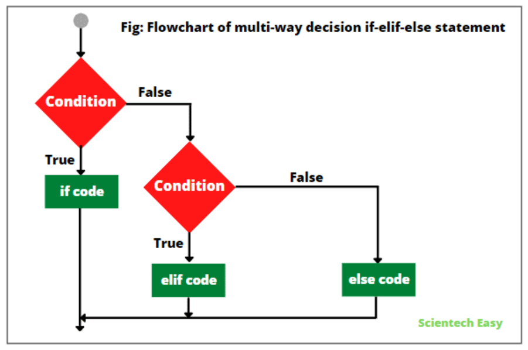

[Source](https://www.scientecheasy.com/2022/10/python-if-elif-else.html/#google_vignette)

### 3. Control Statements

#### 3.1 Break, continue and pass

- Break stops the execution and exit out of it.
- Continue skip the current step and go to the next iteration

```python
for city, pop in cities.items():
    if pop > 200000:
        print('{} is a large city, population is {}'.format(city,pop))
        break
```

for city, pop in cities.items(): if pop > 200000: print('{} is a large city, population is {}'.format(city,pop)) break

```
Boston is a large city, population is 653833
```

### Exercise 4. Replace break with continue

Replace the break with continue to see the difference

You shoud get two results since the code will continue

```python
for city, pop in cities.items():
    if pop > 200000:
        print('{} is a large city, population is {}'.format(city,pop))
        continue
```

for city, pop in cities.items(): if pop > 200000: print('{} is a large city, population is {}'.format(city,pop)) continue

```
Boston is a large city, population is 653833
Worcester is a large city, population is 207621
```

### 4. Functions

A function takes one or more **inputs** and return one of more **outputs**

The code wihitn the function runs only when it is called

```python
# def funtion_name(input):
#    ...
#    return outputs
```

# def funtion_name(input): # ... # return outputs

```python
def find_large_city(input_dict):
    for city,pop in input_dict.items():
        if pop > 200000:
            return '{} is a large city, population is {}'.format(city,pop)
```

def find_large_city(input_dict): for city,pop in input_dict.items(): if pop > 200000: return '{} is a large city, population is {}'.format(city,pop)

```python
cities = {'Boston':653833,
          'Worcester':207621,
          'Springfield':153672,
          'Cambridge':118214}

find_large_city(cities)
```

cities = {'Boston':653833, 'Worcester':207621, 'Springfield':153672, 'Cambridge':118214} find_large_city(cities)

```
'Boston is a large city, population is 653833'
```

### Exercise 5: User-defined function

Given a dictionary parks = { 'Green hill':1875, 'Elm': 1854, 'Institute': 1887, 'Salisbury': 1887 }, write a function to ouput the year of the park user input the park's name

```python
def get_yr(parks, input_name):
    for city, yr in parks.items():
        if city == input_name:
            return yr
```

def get_yr(parks, input_name): for city, yr in parks.items(): if city == input_name: return yr

```python
parks = {
    'Green hill':1875,
    'Elm': 1854,
    'Institute': 1887,
    'Salisbury': 1887
}

get_yr(parks, "Institute")
```

parks = { 'Green hill':1875, 'Elm': 1854, 'Institute': 1887, 'Salisbury': 1887 } get_yr(parks, "Institute")

```
1887
```

4.1 `and` and `or` are logical operators used to combine multiple conditions.

```python
def check_numbers(a, b):
    if a > 0 and b > 0:
        return "Both numbers are positive."
    elif a > 0 or b > 0:
        return "At least one number is positive."
    else:
        return "Neither number is positive."

check_numbers(5,3)
```

def check_numbers(a, b): if a > 0 and b > 0: return "Both numbers are positive." elif a > 0 or b > 0: return "At least one number is positive." else: return "Neither number is positive." check_numbers(5,3)

```
'Both numbers are positive.'
```

### Exercise 6: User-defined function

Write a function to return the temperate from Celsius to Fahrenheir

Fahrenheit = (Celsius * 9/5) + 32

```python
def convert(c):
    f = c*9/5+32
    return f

convert(50)
```

def convert(c): f = c*9/5+32 return f convert(50)

```
122.0
```

### Module

Module is a folder that contain a set of functions you want to include in your applications

Using the `import` statement to use the module

Build-in modules are pre-installed with the Python installation.

```python
## check the built-in modules
help('modules')
```

## check the built-in modules help('modules')

```
Please wait a moment while I gather a list of all available modules...
```

[output not shown]

[output cut: 137 more lines]

[output not shown]

#### random module

`random` module in Python provides functions for generating random numbers

- randint() function return a random integer between a and b: `random.randint(a,b)`

```python
import random
num = random.randint(0,10)
print(num)
```

import random num = random.randint(0,10) print(num)

```
8
```

if you want to use `randint()` directly without the `random` prefix. You can import the function specifically like this

```python
from random import randint
number = randint(1,10)
print(number)
```

from random import randint number = randint(1,10) print(number)

```
7
```

### Exercise : Get the sine of a number from math module

- import `math` module
- use `sin()` function in math module to calculate `sin(3)`

```python
from math import sin

sin(3)
```

from math import sin sin(3)

```
0.1411200080598672
```

### 5. While loop

With the while loop we can execute a set of statements as long as a condition(or expression) is true

Below example is to show the while loop generate a list of numbers but **remember that to increase i, or else the loop will continue forever**

`While expression:`

`statements`

```python
i = 1
while i <= 8:
  print(i)
  i += 1
```

i = 1 while i <= 8: print(i) i += 1

[output not shown]

[figure not shown]

[Source](https://www.geeksforgeeks.org/python-while-loop/)

6. User input

`input()` function get user input, and converting that input from a string to an integer

Syntax:

input(*prompt*) prompt: a string, representing a message before the input

```python
get_name = input("Please input a number")
print("okay, the number is " + get_name)
```

get_name = input("Please input a number") print("okay, the number is " + get_name)

```
okay, the number is 5
```

#### 6.1 input and if

```python
get_num = int(input("Please input a number"))
if get_num <= 5:
    print('smaller than 5')
else:
    print('larger than 5')
```

get_num = int(input("Please input a number")) if get_num <= 5: print('smaller than 5') else: print('larger than 5')

Exercise 7: Guess the Secret Number

Write a python program that generates a random number between 1 and 20. The program will then repeatedly prompt the user to guess the number. The loop will continue until the user guesses the correct number.

```python
import random

# 1. generate a random integer number between 1 and 20


# 2. print a message that tell user the guess range


# 3. Initialize the value of guess number as None

# 4. use a while loop to keep asking the user for guesses


# 5. After each incorrect guess, tell the user whether their guess was too high or too low: using if condition

# 6. When the user guesses correctly, print a congratulatory messag and stop the loop
```

import random # 1. generate a random integer number between 1 and 20 # 2. print a message that tell user the guess range # 3. Initialize the value of guess number as None # 4. use a while loop to keep asking the user for guesses # 5. After each incorrect guess, tell the user whether their guess was too high or too low: using if condition # 6. When the user guesses correctly, print a congratulatory messag and stop the loop

#### 6.2 The break statement

With the break statement we can stop the while loop

```python
i = 1
while i < 8:
  print(i)
  i += 1
  if i == 3:
    break
```

i = 1 while i < 8: print(i) i += 1 if i == 3: break

### 7. Error Handing exception

Error is the common issue in your code, how your responds to these errors, called exceptions.

- **try** | **except** | **finally**
  - **try** statement is used to process a block of code
  - **except** is used to catch the error
  - **finally** always run the code regardless of whether an exception occurred, providing feedback that the process is complete

```python
def calculate(num):
    rst = num/3
    print(rst)
calculate('str')
```

def calculate(num): rst = num/3 print(rst) calculate('str')

```
---------------------------------------------------------------------------
TypeError                                 Traceback (most recent call last)
Cell In[3], line 4
      2     rst = num/3
      3     print(rst)
----> 4 calculate('str')

Cell In[3], line 2, in calculate(num)
      1 def calculate(num):
----> 2     rst = num/3
      3     print(rst)

TypeError: unsupported operand type(s) for /: 'str' and 'int'
```

```python
def calculate(num):
    try:
        rst = num/3
        return rst
    except TypeError:
        print('Please input a valid number')
    finally:
        print("End")

rst_num = calculate('str')
print(rst_num)
# print(calculate(6))
```

def calculate(num): try: rst = num/3 return rst except TypeError: print('Please input a valid number') finally: print("End") rst_num = calculate('str') print(rst_num) # print(calculate(6))

```
Please input a valid number
End
None
```

2024-10-02 2024-10-02